# 情報科学3

モデルの性能評価

矢内 勇生

2021-11-12

## 準備

### パッケージの読み込み

必要なパッケージを読み込む。

```r
pacman::p_load(tidyverse,
               broom,
               irr,
               gmodels,
               caret,
               rsample,
               ISLR)
```

次に、ggplot2のテーマとフォントの設定を行う。自分好みの設定がある場合は自由に変えてよい。

```r
if (.Platform$OS.type == "windows") {
  if (require(fontregisterer)) {
    my_font <- "Yu Gothic"
  } else {
    my_font <- "Japan1"
  }
} else if (capabilities("aqua")) {
  my_font <- "HiraginoSans-W3"
} else {
  my_font <- "IPAexGothic"
}

theme_set(theme_gray(base_size = 9,
                     base_family = my_font))
```

### データの準備

説明のために『Rによる計量政治学』（浅野正彦, 矢内勇生. 2018）で使用されているデータ（hr-data.csv） を使う。

```r
HR <- read_csv("data/hr-data.csv")
```

小選挙区での当落を表すダミー変数（分類問題ではこれを二値の応答変数として扱う）と自民党所属であることを示すダミー変数を作る。

```r
HR <- HR %>%
  mutate(wlsmd = ifelse(wl == "当選", 1, 0),
         LDP = ifelse (party == "LDP", 1, 0))
```

## 分類の性能評価

### ロジスティック回帰による分類

ロジスティック回帰 (2) で実施した内容の繰り返しだが、 2005年のデータを取り出し、候補者の小選挙区における当落 (wlsmd) を縦軸に、それまでの当選回数 (previous) を横軸にした散布図を表示してみよう。

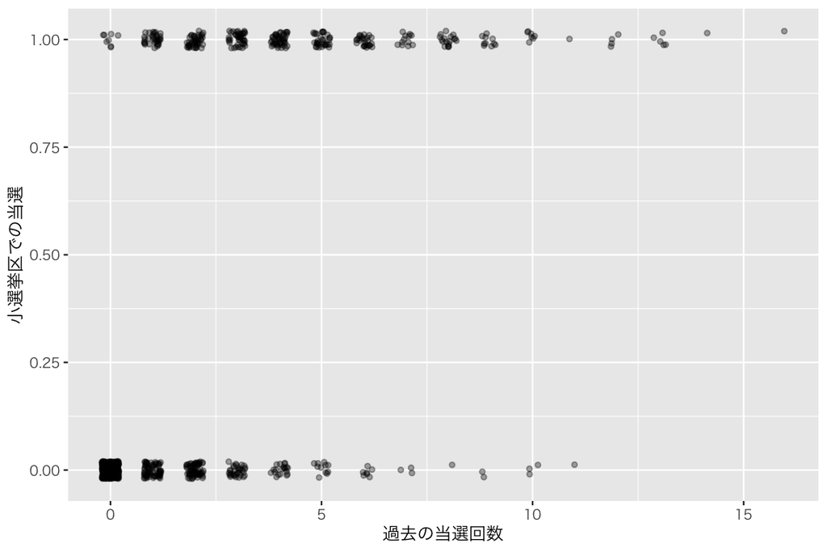

```r
HR2005 <- HR %>%
  filter(year == 2005)
p <- ggplot(HR2005, aes(previous, wlsmd)) +
  geom_jitter(size = 1,
              alpha = 1/3,
              height = 0.02,
              width = 0.2) +
  labs(x = "過去の当選回数",
       y = "小選挙区での当選")
plot(p)
```

このデータを使い、当落を応答変数、過去の当選回数を説明変数として、ロジスティック回帰分析を行う。

```r
fit <- glm(wlsmd ~ previous,
           data = HR2005,
           family = binomial(link = "logit"))
tidy(fit, conf.int = TRUE) %>%
  select(term, estimate, std.error, conf.low, conf.high)
```

```
## # A tibble: 2 × 5
##   term        estimate std.error conf.low conf.high
##   <chr>          <dbl>     <dbl>    <dbl>     <dbl>
## 1 (Intercept)   -2.34     0.133    -2.61     -2.09
## 2 previous       0.713    0.0475    0.623     0.809
```

この結果を図示しよう。

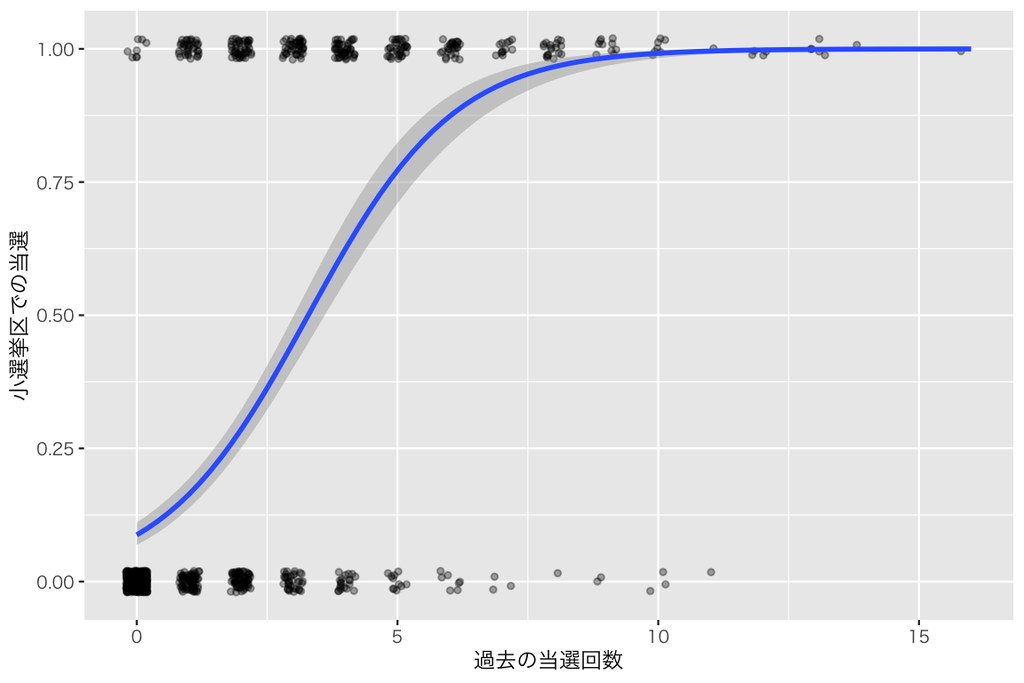

```r
p_fit <- p +
  geom_smooth(method = "glm",
              method.args = list(family = binomial(link = "logit")))
plot(p_fit)
```

次に、成功確率（当選確率）の予測値を求める。

```r
pred <- predict(fit, type = "response")
```

予測確率が0.5以上の候補者を「当選 (1)」に、0.5未満の候補者を「落選 (0)」に分類する。

```r
y_hat <- ifelse(pred >= 0.5, 1, 0)
```

分類結果は、

```r
table(y_hat)
```

```
## y_hat
##   0   1
## 773 216
```

である。

### 分類性能の評価

混同行列を作る。

```r
CrossTable(x = HR2005$wlsmd,
           y = y_hat,
           dnn = c("実際の当落", "当落の予測"),
           prop.r = FALSE,　# 行%は表示しない
           prop.c = FALSE,　# 列%は表示しない
           prop.t = TRUE,   # 合計%は表示する
           prop.chisq = FALSE) # chi^2値は表示しない
```

```
##
##
##    Cell Contents
## |-------------------------|
## |                       N |
## |         N / Table Total |
## |-------------------------|
##
##
## Total Observations in Table:  989
##
##
##              | 当落の予測
##   実際の当落 |         0 |         1 | Row Total |
## -------------|-----------|-----------|-----------|
##            0 |       641 |        48 |       689 |
##              |     0.648 |     0.049 |           |
## -------------|-----------|-----------|-----------|
##            1 |       132 |       168 |       300 |
##              |     0.133 |     0.170 |           |
## -------------|-----------|-----------|-----------|
## Column Total |       773 |       216 |       989 |
## -------------|-----------|-----------|-----------|
##
##
```

この予測の正解率$p_o$は、

```r
(p_o <- (641 + 168) / 989)
```

```
## [1] 0.817998
```

である。

ランダムに分類を行ったときに分類が正しくなる確率$p_e$は、

```r
(p_e <- (773/989) * (689/989) + (216/989) * (300 / 989))
```

```
## [1] 0.6107598
```

である。

コーエンの$\kappa$は
$$\kappa = \frac{p_o - p_e}{1 - p_e}$$
なので、

```r
(p_o - p_e) / (1 - p_e)
```

```
## [1] 0.5324172
```

である。

この値は、**irr**パッケージの`kappa2()`で求めることができる。1列目が観測された応答変数、2列目が予測値であるデータフレームを渡す必要がある。

```r
df <- tibble(observed = HR2005$wlsmd,
             predicted = y_hat,)
kappa2(df)
```

```
##  Cohen's Kappa for 2 Raters (Weights: unweighted)
##
##  Subjects = 989
##    Raters = 2
##     Kappa = 0.532
##
##         z = 17.2
##   p-value = 0
```

混同行列に表示されている値を利用して計算した結果と同じ$\kappa$が得られた。 $\kappa$の値のみ取り出したいときは、次のようにする。

```r
kappa2(df)$value
```

```
## [1] 0.5324172
```

正解率は0.82でそれなりに良さそうに見えるが、ランダムに予測してもそこそこ当たることを考慮に入れると、このモデルの予測性能はあまり高くないということがわかる。

分類性能を測るその他の指標やROC曲線、AUCについては過去の資料を参照されたい。

### 10分割交差検証

$k$分割交差検証を$k=10$で行ってみよう。

**caret**パッケージの `createFolds()` で10個のフォールドを作る。

```r
HR2005_folds <- createFolds(HR2005$wlsmd, k = 10)
```

```r
glimpse(HR2005_folds)
```

```
## List of 10
##  $ Fold01: int [1:99] 2 13 18 28 61 69 86 87 110 121 ...
##  $ Fold02: int [1:99] 20 65 78 98 114 116 117 122 125 129 ...
##  $ Fold03: int [1:99] 6 7 32 35 44 49 70 73 75 80 ...
##  $ Fold04: int [1:99] 3 5 12 24 47 63 71 72 79 81 ...
##  $ Fold05: int [1:99] 21 36 42 66 77 90 92 93 103 107 ...
##  $ Fold06: int [1:99] 1 16 22 23 38 40 50 59 67 76 ...
##  $ Fold07: int [1:99] 8 30 34 41 48 52 53 55 56 57 ...
##  $ Fold08: int [1:98] 11 15 25 29 39 46 51 60 62 95 ...
##  $ Fold09: int [1:99] 9 14 19 31 37 43 45 64 74 102 ...
##  $ Fold10: int [1:99] 4 10 17 26 27 33 54 89 99 100 ...
```

10個のフォールドができている。このリストのそれぞれの要素に含まれる数値は、データセットの行番号で、どの行がどのfold に割り当てられたかを示している。

作ったそれぞれのフォールドをテストデータに、残りを学習データとして用いてコーエンの$\kappa$を計算する。 まず、1つのフォールドについて$\kappa$を計算する関数を作る。

```r
logistic_cv <- function(fold) {
  df_train <- HR2005[-fold, ]
  df_test <- HR2005[fold, ]
  fit <- glm(wlsmd ~ previous,
             data = df_train,
             family = binomial(link = "logit"))
  pred <- predict(fit, newdata = df_test, type = "response")
  df_k <- tibble(observed = df_test$wlsmd,
                 predicted = ifelse(pred > 0.5, 1, 0))
  kappa2(df_k)$value
}
```

10個のフォールドのそれぞれでこの関数を使って$\kappa$の値を求め、10個の$\kappa$の平均値を求める。

```r
HR2005_folds %>%
  map(.f = logistic_cv) %>%
  unlist() %>%
  mean()
```

```
## [1] 0.5303089
```

やはり、あまり性能は良くないようだ。

## 回帰の性能評価

2005年の衆院選データについて、候補者の小選挙区における得票率 `voteshare` を応答変数とする回帰分析を行う。 説明変数として、以下の3つを使う。

- 選挙費用（100万円）：`expm`
- 過去の当選回数：`previous`
- 自民党ダミー: `LDP`

自民党ダミーを含まないモデル1と、自民党ダミーを含むモデル2を比べる。

```r
f1 <- formula(voteshare ~ expm_c + previous)
f2 <- formula(voteshare ~ expm_c + previous + LDP)
```

性能評価のために、データを訓練用とテスト用に分ける。

```r
HR05 <- HR2005 %>%
  filter(!is.na(expm)) %>%
  mutate(expm_c = expm - mean(expm))

HR05_split <- initial_split(HR05, prop = 2/3)
HR05_train <- training(HR05_split)
HR05_test <- testing(HR05_split)
```

訓練用データで学習を行う。

```r
ols1 <- lm(f1,
           data = HR05_train)
ols2 <- lm(f2,
           data = HR05_train)
```

自由度調整済み決定係数は、

```r
cbind(summary(ols1)$adj.r.squared,
      summary(ols2)$adj.r.squared)
```

```
##           [,1]      [,2]
## [1,] 0.6245738 0.6878217
```

であり、モデル2のほうが当てはまりがよい。

**訓練**データでRMSEを計算する。

```r
rmse1 <- (HR05_train$voteshare - ols1$fitted.values)^2 %>%
  sum() %>%
  sqrt()
rmse2 <- (HR05_train$voteshare - ols2$fitted.values)^2 %>%
  sum() %>%
  sqrt()
cbind(rmse1, rmse2)
```

```
##         rmse1   rmse2
## [1,] 298.3754 271.875
```

（当てはまり良いので当然だが）RMSEもモデル2のほうが小さい。

**テスト**データでRMSEを計算する。

```r
yhat1 <- predict(ols1, newdata = HR05_test)
yhat2 <- predict(ols2, newdata = HR05_test)
rmse1t <- (HR05_test$voteshare - yhat1)^2 %>%
  sum() %>%
  sqrt()
rmse2t <- (HR05_test$voteshare - yhat2)^2 %>%
  sum() %>%
  sqrt()
cbind(rmse1t, rmse2t)
```

```
##        rmse1t   rmse2t
## [1,] 195.5505 180.4921
```

やはりモデル2のほうが性能が良い。

### 10分割交差検証

$k$分割交差検証を$k=10$で行ってみよう。

フォールドを作り直す。

```r
HR05_folds <- createFolds(HR05$wlsmd, k = 10)
```

作ったそれぞれのフォールドをテストデータに、残りを学習データとして用いてRMSEを計算する。 まず、1つのフォールドについてRMSEを計算する関数を作る。

```r
ols_cv <- function(fold, formula) {
  df_train <- HR05[-fold, ]
  df_test <- HR05[fold, ]
  fit <- lm(formula,
            data = df_train)
  yhat <- predict(fit, newdata = df_test)
  (df_test$voteshare - yhat)^2 %>%
    sum() %>%
    sqrt()
}
```

```r
m1 <- HR05_folds %>%
  map(.f = ols_cv,
      formula = f1) %>%
  unlist() %>%
  mean()

m2 <- HR05_folds %>%
  map(.f = ols_cv,
      formula = f2) %>%
  unlist() %>%
  mean()

cbind(m1, m2)
```

```
##           m1       m2
## [1,] 113.055 103.3513
```

やはり、モデル2のほうが予測性能が良さそうだ。

授業の内容に戻る